# Exploring the BRFSS data

## Setup

### Load packages

```r
library(ggplot2)
library(ggmosaic)
library(dplyr)
```

### Load data

```r
load("brfss2013.RData")
```

## Part 1: Data

In this work we will deal with the Behavioral Risk Factor Surveillance System (BRFSS) dataset, produced in 2013. It was collected from the non-institutionalized adult population (18 years of age and older) residing in the US and participating US territories, namely, all 50 states, the District of Columbia, Puerto Rico, Guam, American Samoa, Federated States of Micronesia, Palau. The sample was built by surveing the random landline or cellular telephone, it’s size is about 490K observations and research results can be generalized to the population described above (due to random nature of collecting data). As the BRFSS is the result of observational study, we can not make causal conclusions. Although sample was built based on random selection, there might be a bias related to the method of collecting data - telephone calls. People working at night, travelers, households without telephone, people who do not speak English or Spanish (the languages used for surveys) - that’s the incomplete list of thouse who may not be represented in BRFSS dataset.

Although we can not establish causal connections between variables of interest, we can research association between them, so let’s try to do it by answering on the next three questions. * * *

## Part 2: Research questions

**Research quesion 1:**

Is the level of education of working people related to higher income?

**Research quesion 2:**

Does somehow people’s weight related to vegetables consumption?

**Research quesion 3:**

Is self employed mans who sleeps less than it is necessary, drink more alcohol than employed who sleeps enough?

## Part 3: Exploratory data analysis

### Research question 1: Is the level of education of working people related to higher income?

Let’s dive into Codebook in order to select variables that can help us answer this question.

As for employment status, it’s ‘employ1’ variable. Take a look at it quickly.

```r
str(brfss2013$employ1)
```

```
##  Factor w/ 8 levels "Employed for wages",..: 7 1 1 7 7 1 1 7 7 5 ...
```

```r
levels(brfss2013$employ1)
```

```
## [1] "Employed for wages"               "Self-employed"
## [3] "Out of work for 1 year or more"   "Out of work for less than 1 year"
## [5] "A homemaker"                      "A student"
## [7] "Retired"                          "Unable to work"
```

```r
brfss2013 %>%
  group_by(employ1) %>%
  summarize(count=n())
```

```
## # A tibble: 9 x 2
##   employ1                           count
##   <fct>                             <int>
## 1 Employed for wages               202200
## 2 Self-employed                     39832
## 3 Out of work for 1 year or more    14074
## 4 Out of work for less than 1 year  12242
## 5 A homemaker                       31647
## 6 A student                         12682
## 7 Retired                          138259
## 8 Unable to work                    37453
## 9 <NA>                               3386
```

It has enough data to get subset of working people, so we can use it in research.

For education level the Codebook offers two variables: **educa** and calculated variable **_educag**. While **educa** has six levels

```r
levels(brfss2013$educa)
```

```
## [1] "Never attended school or only kindergarten"
## [2] "Grades 1 through 8 (Elementary)"
## [3] "Grades 9 though 11 (Some high school)"
## [4] "Grade 12 or GED (High school graduate)"
## [5] "College 1 year to 3 years (Some college or technical school)"
## [6] "College 4 years or more (College graduate)"
```

**_educag** has four (in it’s internals R replaces **_educag** with **X_educag**, so we will refer the latter)

```r
levels(brfss2013$X_educag)
```

```
## [1] "Did not graduate high school"
## [2] "Graduated high school"
## [3] "Attended college or technical school"
## [4] "Graduated from college or technical school"
```

This four levels of educations is enough to understand the problem, so we will use **_educag** in our research.

Similary, let’s check income variable. The Codebook offers two variables: **income2** and calculated variable**_incomg**.

```r
levels(brfss2013$income2)
```

```
## [1] "Less than $10,000" "Less than $15,000" "Less than $20,000"
## [4] "Less than $25,000" "Less than $35,000" "Less than $50,000"
## [7] "Less than $75,000" "$75,000 or more"
```

```r
levels(brfss2013$X_incomg)
```

```
## [1] "Less than $15,000"            "$15,000 to less than $25,000"
## [3] "$25,000 to less than $35,000" "$35,000 to less than $50,000"
## [5] "$50,000 or more"
```

**X_incomeg** seems detailed enough so we will use it.

Let’s take a closer look at variables.

First of all, let’s extract variables that we are interested into separate dataframe in order to work with less data volume to speedup calculations and do not mutate original dataframe if we will need. Also filter records to select data only for working peoples.

```r
education.income <- brfss2013 %>%
  filter(brfss2013$employ1 %in% c('Employed for wages', 'Self-employed')) %>%
  select(income=X_incomg, education=X_educag)

head(education.income)
```

```
##                         income                                  education
## 1              $50,000 or more       Attended college or technical school
## 2              $50,000 or more Graduated from college or technical school
## 3              $50,000 or more Graduated from college or technical school
## 4                         <NA>                      Graduated high school
## 5              $50,000 or more Graduated from college or technical school
## 6 $15,000 to less than $25,000                      Graduated high school
```

Let’s check variables on the subject of NA (and related garbage) values.

```r
education.income %>%
  group_by(education) %>%
  summarize(count=n())
```

```
## # A tibble: 5 x 2
##   education                                   count
##   <fct>                                       <int>
## 1 Did not graduate high school                11432
## 2 Graduated high school                       59881
## 3 Attended college or technical school        66270
## 4 Graduated from college or technical school 103945
## 5 <NA>                                          504
```

```r
education.income %>%
  group_by(income) %>%
  summarize(count=n())
```

```
## # A tibble: 6 x 2
##   income                        count
##   <fct>                         <int>
## 1 Less than $15,000             10235
## 2 $15,000 to less than $25,000  26714
## 3 $25,000 to less than $35,000  22147
## 4 $35,000 to less than $50,000  33144
## 5 $50,000 or more              127027
## 6 <NA>                          22765
```

As we can see, there is NA values. They are useless in the context of current research, so let’s get rid of them.

```r
education.income <- na.omit(education.income)

education.income %>%
  group_by(education) %>%
  summarize(count=n())
```

```
## # A tibble: 4 x 2
##   education                                  count
##   <fct>                                      <int>
## 1 Did not graduate high school               10029
## 2 Graduated high school                      52996
## 3 Attended college or technical school       60090
## 4 Graduated from college or technical school 95953
```

```r
education.income %>%
  group_by(income) %>%
  summarize(count=n())
```

```
## # A tibble: 5 x 2
##   income                        count
##   <fct>                         <int>
## 1 Less than $15,000             10220
## 2 $15,000 to less than $25,000  26671
## 3 $25,000 to less than $35,000  22118
## 4 $35,000 to less than $50,000  33123
## 5 $50,000 or more              126936
```

Now, when we have clean dataset, it’s time to take a look at distribution of each variable.

```r
education.income %>%
  group_by(education) %>%
  summarize(freq=sprintf("%.2f %%", n()/nrow(education.income) * 100))
```

```
## # A tibble: 4 x 2
##   education                                  freq
##   <fct>                                      <chr>
## 1 Did not graduate high school               4.58 %
## 2 Graduated high school                      24.19 %
## 3 Attended college or technical school       27.43 %
## 4 Graduated from college or technical school 43.80 %
```

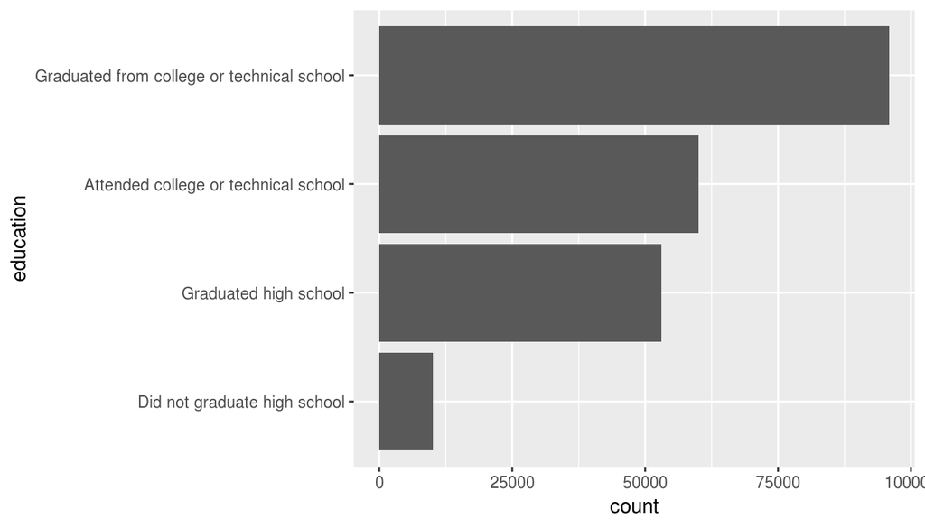

```r
ggplot(education.income, aes(x=education)) + geom_bar() + coord_flip()
```

From the frequency table and bar plot above we can learn that the fraction of those who has no formal education is really small and is near 5%. The next two groups are nearly equal, the fraction of those who graduated high school and those who attended college or technical school are about 24% and 27% respectively. If we combine those groups we will see that the number of people who graduated high school, but didn’t graduate college is dominant and equal 52%.

```r
education.income %>%
  group_by(income) %>%
  summarize(freq=sprintf("%.2f %%", n()/nrow(education.income) * 100))
```

```
## # A tibble: 5 x 2
##   income                       freq
##   <fct>                        <chr>
## 1 Less than $15,000            4.67 %
## 2 $15,000 to less than $25,000 12.17 %
## 3 $25,000 to less than $35,000 10.10 %
## 4 $35,000 to less than $50,000 15.12 %
## 5 $50,000 or more              57.94 %
```

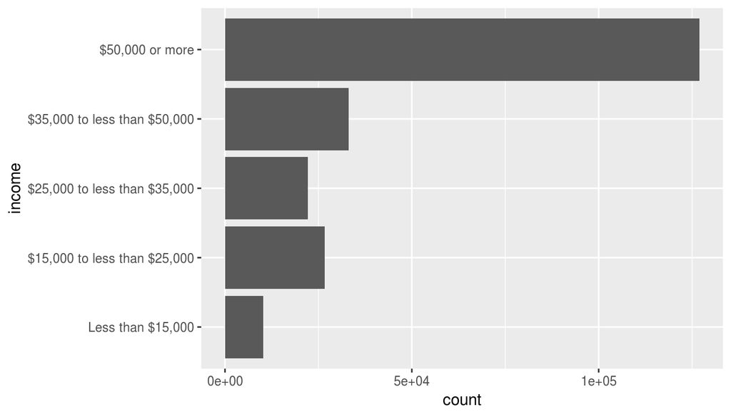

```r
ggplot(education.income, aes(x=income)) + geom_bar() + coord_flip()
```

We can see, that the number of working Americans who earn realy well is big and is about 58% of all working peoples. On other side the ratio of working people who earn less than 15K/year is small and is about 5%.

```r
table.education.margin <- table(education.income$education, education.income$income) %>% prop.table(1)
colnames(table.education.margin) <- c('< $15K', '$15K-$25K', '$25K-$35K', '$35K-$50K', '$50K >')
table.education.margin
```

```
##
##                                                  < $15K  $15K-$25K
##   Did not graduate high school               0.20660086 0.34170904
##   Graduated high school                      0.07477923 0.20012831
##   Attended college or technical school       0.04601431 0.13523049
##   Graduated from college or technical school 0.01479891 0.04702302
##
##                                               $25K-$35K  $35K-$50K
##   Did not graduate high school               0.16073387 0.13331339
##   Graduated high school                      0.15006793 0.19135406
##   Attended college or technical school       0.12141787 0.17903145
##   Graduated from college or technical school 0.05478724 0.11346180
##
##                                                  $50K >
##   Did not graduate high school               0.15764284
##   Graduated high school                      0.38367047
##   Attended college or technical school       0.51830587
##   Graduated from college or technical school 0.76992903
```

Above the contingency table with row proportions. Because the income rates vary between the levels of graduation, we can conclude that the *income* and *education* variables are associated.

```r
table.income.margin <- table(education.income$education, education.income$income) %>% prop.table(2)
colnames(table.income.margin) <- c('< $15K', '$15K-$25K', '$25K-$35K', '$35K-$50K', '$50K >')
table.income.margin
```

```
##
##                                                  < $15K  $15K-$25K
##   Did not graduate high school               0.20273973 0.12849162
##   Graduated high school                      0.38776908 0.39766038
##   Attended college or technical school       0.27054795 0.30467549
##   Graduated from college or technical school 0.13894325 0.16917251
##
##                                               $25K-$35K  $35K-$50K
##   Did not graduate high school               0.07288182 0.04036470
##   Graduated high school                      0.35957139 0.30616188
##   Attended college or technical school       0.32986708 0.32478942
##   Graduated from college or technical school 0.23767972 0.32868400
##
##                                                  $50K >
##   Did not graduate high school               0.01245510
##   Graduated high school                      0.16018308
##   Attended college or technical school       0.24535987
##   Graduated from college or technical school 0.58200195
```

Above the contingency table with column proportions. Because the education rates vary between the levels of income, we can confirm that the *income* and *education* variables are associated.

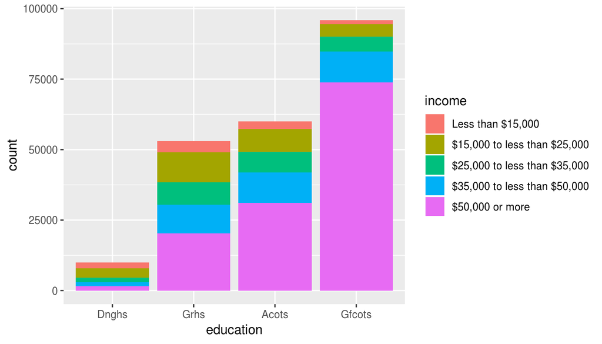

```r
ggplot(education.income, aes(x=education, fill=income)) + geom_bar() + scale_x_discrete(labels = abbreviate)
```

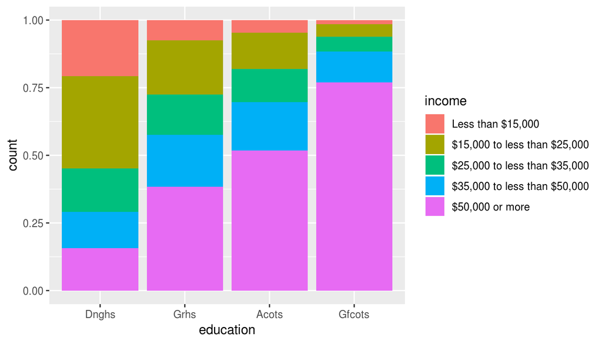

```r
ggplot(education.income, aes(x=education, fill=income)) + geom_bar(position='fill') + scale_x_discrete(labels = abbreviate)
```

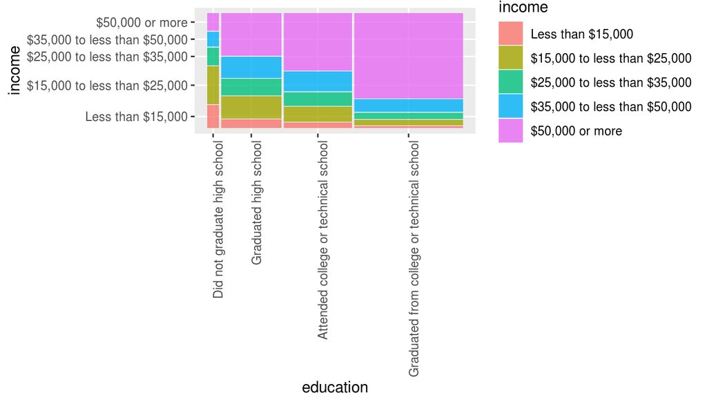

```r
ggplot(education.income) + geom_mosaic(aes(x = product(education), fill=income)) + theme(axis.text.x = element_text(angle = 90, hjust = 1))
```

By looking at the three diagrams above we can see that there is a strong tendency for income level to grow when education level grow. But the number of income and education levels seems too big to intuitively understand the results. As a suggestion, it will be more simpler, if we will make 3 levels of income (poor, average, good) and 3 for education (didn’t graduate high school, graduated high school and graduated from college or technical school). The results of such transformations below.

```r
education.income$education <- recode(education.income$education, "Attended college or technical school" = "Graduated high school")
```

```r
education.income %>%
  group_by(education) %>%
  summarize(freq=sprintf("%.2f %%", n()/nrow(education.income) * 100))
```

```
## # A tibble: 3 x 2
##   education                                  freq
##   <fct>                                      <chr>
## 1 Did not graduate high school               4.58 %
## 2 Graduated high school                      51.62 %
## 3 Graduated from college or technical school 43.80 %
```

More than 50% of working people are graduated highschool and 44% graduated from college. Awesome! Only 5% have no formal education.

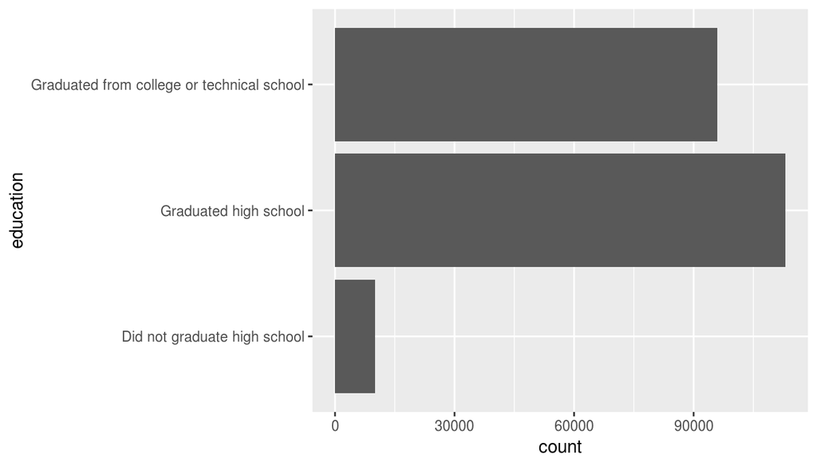

```r
ggplot(education.income, aes(x=education)) + geom_bar() + coord_flip()
```

```r
education.income$income <- recode(education.income$income, "$15,000 to less than $25,000" = "$15,000 to less than $50,000",
                                                            "$25,000 to less than $35,000" = "$15,000 to less than $50,000",
                                                            "$35,000 to less than $50,000" = "$15,000 to less than $50,000")
```

```r
education.income %>%
  group_by(income) %>%
  summarize(freq=sprintf("%.2f %%", n()/nrow(education.income) * 100))
```

```
## # A tibble: 3 x 2
##   income                       freq
##   <fct>                        <chr>
## 1 Less than $15,000            4.67 %
## 2 $15,000 to less than $50,000 37.39 %
## 3 $50,000 or more              57.94 %
```

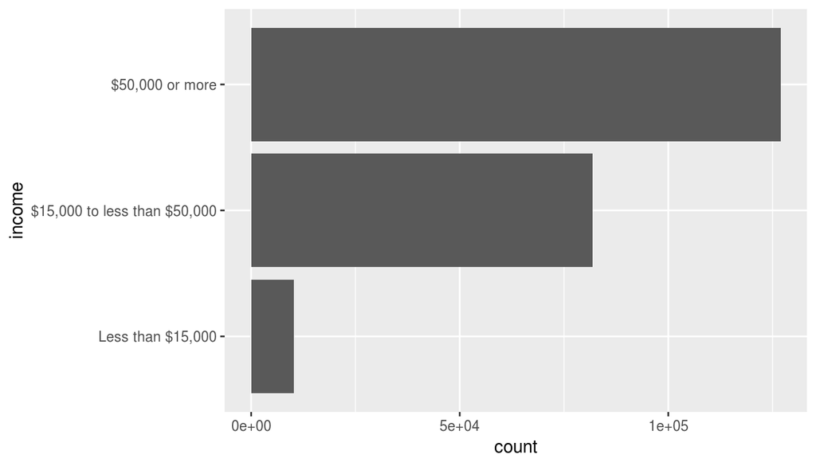

```r
ggplot(education.income, aes(x=income)) + geom_bar() + coord_flip()
```

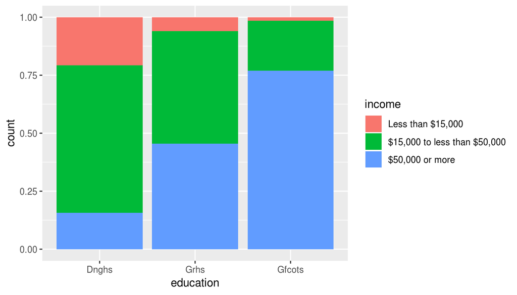

```r
ggplot(education.income, aes(x=education, fill=income)) + geom_bar(position='fill') + scale_x_discrete(labels = abbreviate)
```

```r
table.education.margin <- table(education.income$education, education.income$income) %>% prop.table(1)
colnames(table.education.margin) <- c('< $15K', '$15K-$50K', '$50K >')
table.education.margin
```

```
##
##                                                  < $15K  $15K-$50K
##   Did not graduate high school               0.20660086 0.63575631
##   Graduated high school                      0.05949454 0.48529438
##   Graduated from college or technical school 0.01479891 0.21527206
##
##                                                  $50K >
##   Did not graduate high school               0.15764284
##   Graduated high school                      0.45521108
##   Graduated from college or technical school 0.76992903
```

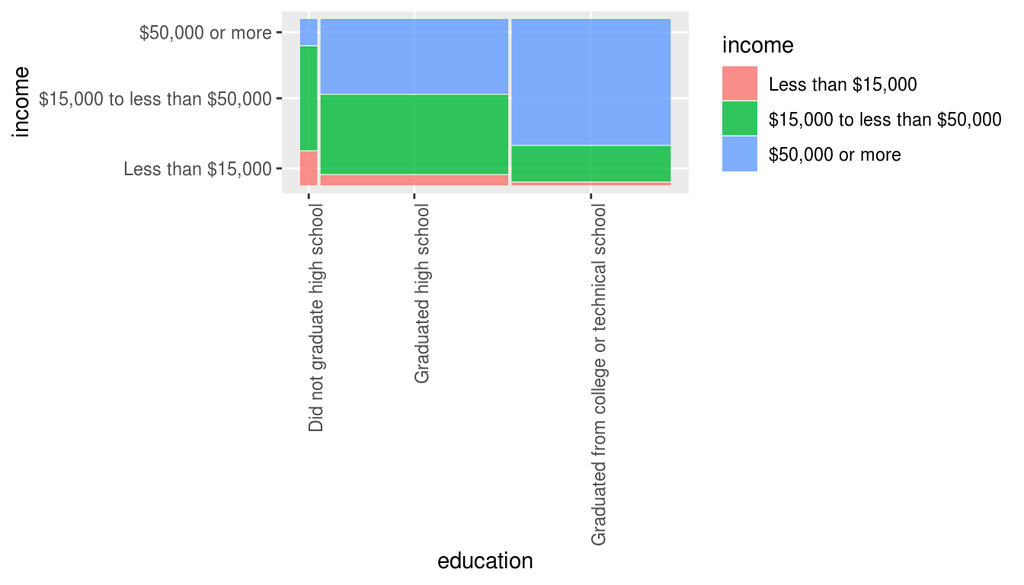

```r
ggplot(education.income) + geom_mosaic(aes(x = product(education), fill=income)) + theme(axis.text.x = element_text(angle = 90, hjust = 1))
```

The final thoughts on the question “Is the level of education of working people related to higher income?”: yes, it is. But by looking at the diagrams above we can make a couple of other conclusions. The ratio of those who earn less than 15k is small, around 5%. Even among working people without formal education there is a 15% ratio of those who earn greater than 50K. And even among people who graduated from college 1,4% earn less than 15k. While there is such unmotivated results, the overall trending is - learn, and there will be a good chance for you to earn enough money.

### Research question 2: Does somehow people’s weight related to vegetables consumption?

In order to answer this question let’s look at the variables that the codebook can provide. As for weight, there is a reference to **weight2** reported weight in pounds (without shoes). But this variable has mixed pounds/kilograms values (kilograms are used for values bigger than 9000), so we should preprocess it to achieve monotony. For our happiness dataset compilers already did this job and provide us with **wtkg3** - computed weight in kilograms. Let’s explore it. Note, as codebook states, there is 2 implied decimal places, so the value 9754 kg we should perceive as 97,54 kg.

First of all, let’s extract variables that we are interested into separate dataframe in order to work with less data volume to speedup calculations and do not mutate original dataframe if we will need. Also let’s remove any NA from new data frame.

```r
weight.vegetables <- data.frame(weight=brfss2013$wtkg3, vegetables=brfss2013$X_vegesum) %>% na.omit()
head(weight.vegetables)
```

```
##   weight vegetables
## 1  11340         53
## 2   5761        148
## 3   7257        191
## 4   5806        136
## 5  12020        243
## 6  10206        143
```

```r
anyNA(weight.vegetables)
```

```
## [1] FALSE
```

At first, let’s explore ‘weight’ variable.

```r
weight <- weight.vegetables$weight
```

```r
str(weight)
```

```
##  int [1:445193] 11340 5761 7257 5806 12020 10206 4808 10659 7711 10206 ...
```

It’s a descrete numeric variable.

```r
range(weight)
```

```
## [1]     1 29030
```

With range of values from 1 (person with weight of 0,01 kilogramm???) to 290,3 kilograms.

Let’s say a couple of words about central tendency.

```r
mean(weight)
```

```
## [1] 8016.406
```

Mean roughly equal to 80 kg.

```r
median(weight)
```

```
## [1] 7711
```

And median roughly equal to 77 kg.

As the mean greater than median, we can suggest it’s the right skewed distribution.

As for dispersion:

```r
paste(
  'Variance: ', round(var(weight)), '\n',
  'Standard deviation: ', round(sd(weight)), '\n',
  'IQR: ', round(IQR(weight)),
  sep = ''
) %>% cat
```

```
## Variance: 4090069
## Standard deviation: 2022
## IQR: 2495
```

Very dispersed dataset with dense IQR.

Let’s take a look at how the distribution is looks like.

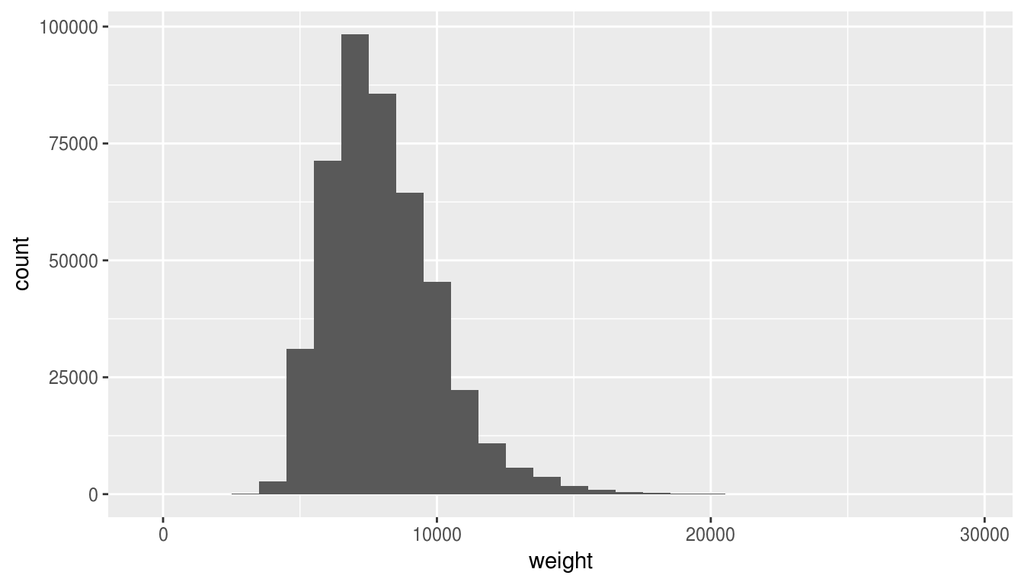

```r
ggplot(data.frame(weight), aes(x=weight)) + geom_histogram()
```

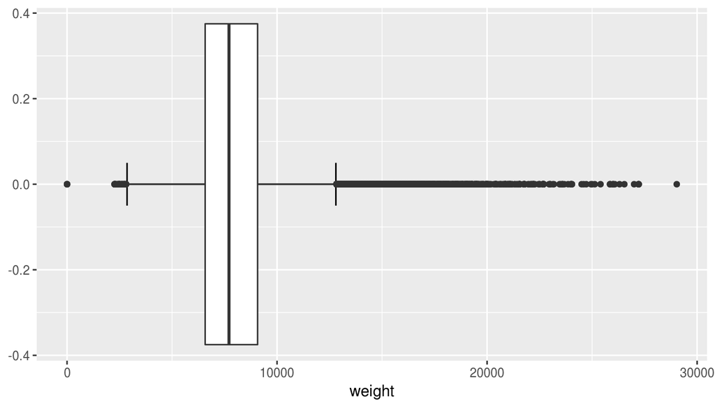

```r
ggplot(data.frame(weight), aes(y=weight)) + stat_boxplot(geom = 'errorbar', width = 0.1) + geom_boxplot() + coord_flip()
```

```r
quantile(weight)
```

```
##    0%   25%   50%   75%  100%
##     1  6577  7711  9072 29030
```

```r
q1 <- 6577
q3 <- 9072
iqr <- IQR(weight)
```

A commonly used rule says that low outliers are below Q1-1.5*IQR and high outliers are above Q3+1.5*IQR, so lets find those borders.

```r
outliers.border.low <- q1 - 1.5 * iqr
outliers.border.high <- q3 + 1.5 * iqr
```

And check how many outliers we have.

```r
length(weight[weight < outliers.border.low | weight > outliers.border.high])
```

```
## [1] 10471
```

```r
10471/length(weight)
```

```
## [1] 0.02352014
```

Not so much, just about 2%. Let’s go futher without them and remove outliers from variable ‘weight’ and from dataset ‘weight.vegetables’.

```r
weight <- weight[weight >= outliers.border.low & weight <= outliers.border.high]
```

```r
weight.vegetables <- subset(weight.vegetables, weight >= outliers.border.low & weight <= outliers.border.high)
```

Let’s check how distribution whithout outliers is looks like.

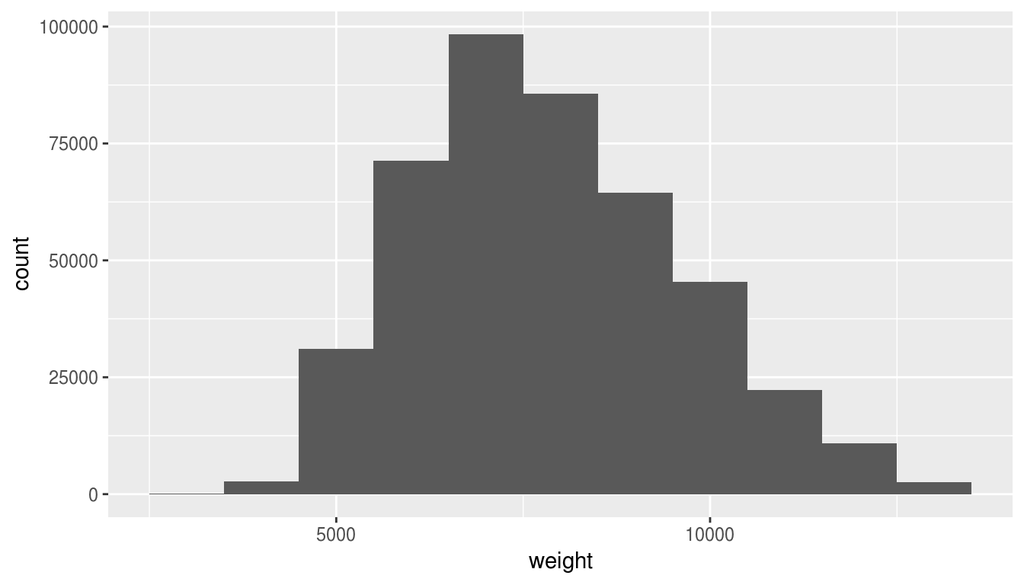

```r
ggplot(data.frame(weight), aes(x=weight)) + geom_histogram(binwidth = 1000)
```

Unimodal, slightly skewed to the right.

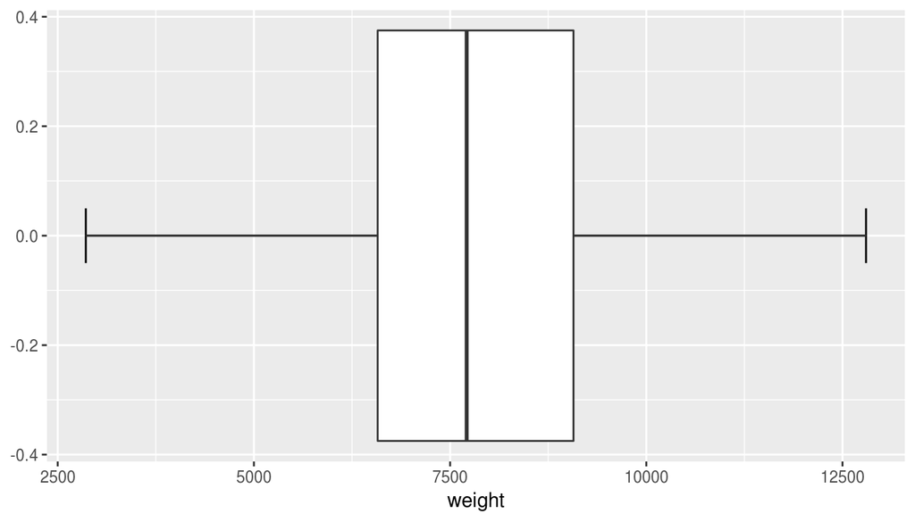

```r
ggplot(data.frame(weight), aes(y=weight)) + stat_boxplot(geom = 'errorbar', width = 0.1) + geom_boxplot() + coord_flip()
```

At second, let’s explore ‘vegetables’ variable.

```r
vegetables <- weight.vegetables$vegetables
```

```r
str(vegetables)
```

```
##  num [1:434722] 53 148 191 136 243 143 216 172 114 44 ...
```

It’s a descrete numeric variable.

```r
range(vegetables)
```

```
## [1]     0 19827
```

With range of values from 0 (no vegetables consumption) to 19827 (???).

Let’s say a couple of words about central tendency.

```r
mean(vegetables)
```

```
## [1] 190.4984
```

```r
median(vegetables)
```

```
## [1] 166
```

As the mean greater than median, we can suggest it’s the right skewed distribution.

As for dispersion:

```r
paste(
  'Variance: ', round(var(vegetables)), '\n',
  'Standard deviation: ', round(sd(vegetables)), '\n',
  'IQR: ', round(IQR(vegetables)),
  sep = ''
) %>% cat
```

```
## Variance: 22803
## Standard deviation: 151
## IQR: 138
```

Very dispersed dataset with dense IQR.

Let’s take a look at how the distribution is looks like.

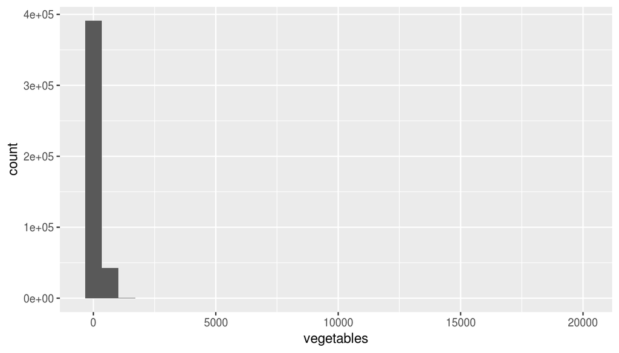

```r
ggplot(data.frame(vegetables), aes(x=vegetables)) + geom_histogram()
```

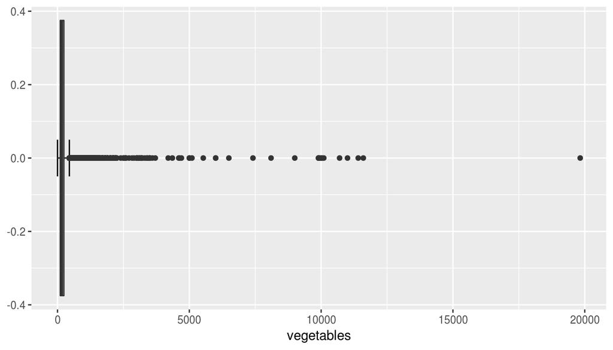

```r
ggplot(data.frame(vegetables), aes(y=vegetables)) + stat_boxplot(geom = 'errorbar', width = 0.1) + geom_boxplot() + coord_flip()
```

By looking at graphs we can confirm the suggestion that the distribution skewed to the right. But also we can note that while the IQR is condensed, there is a lot of outliers. What to do with them? Let’s explore if we can get rid of them. First of all, let’s find quartiles Q1 and Q3 to define borders of IQR.

```r
quantile(vegetables)
```

```
##    0%   25%   50%   75%  100%
##     0   105   166   243 19827
```

```r
q1 <- 104
q3 <- 243
iqr <- IQR(vegetables)
```

A commonly used rule says that low outliers are below Q1-1.5*IQR and high outliers are above Q3+1.5*IQR, so lets find those borders.

```r
outliers.border.low <- q1 - 1.5 * iqr
outliers.border.high <- q3 + 1.5 * iqr
```

And check how many outliers we have.

```r
length(vegetables[vegetables < outliers.border.low | vegetables > outliers.border.high])
```

```
## [1] 17397
```

```r
10471/length(vegetables)
```

```
## [1] 0.02408666
```

```r
vegetables <- vegetables[vegetables >= outliers.border.low & vegetables <= outliers.border.high]
```

```r
weight.vegetables <- subset(weight.vegetables, vegetables >= outliers.border.low & vegetables <= outliers.border.high)
```

Let’s check how distribution whithout outliers is looks like.

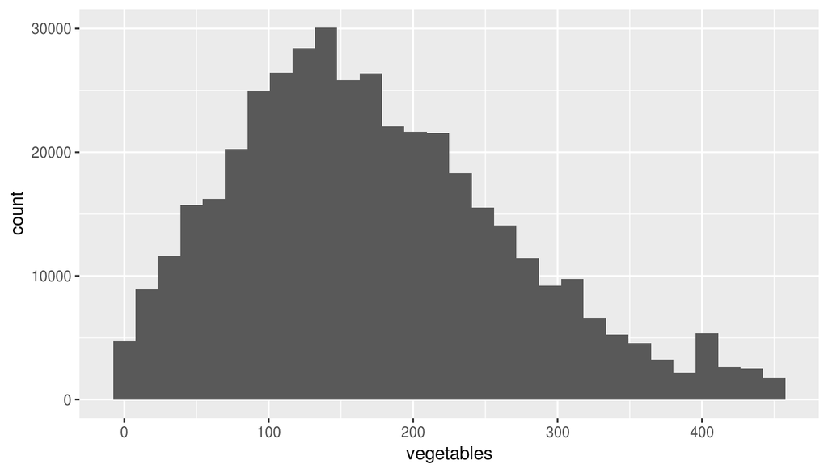

```r
ggplot(data.frame(vegetables), aes(x=vegetables)) + geom_histogram()
```

Unimodal, slightly skewed to the right.

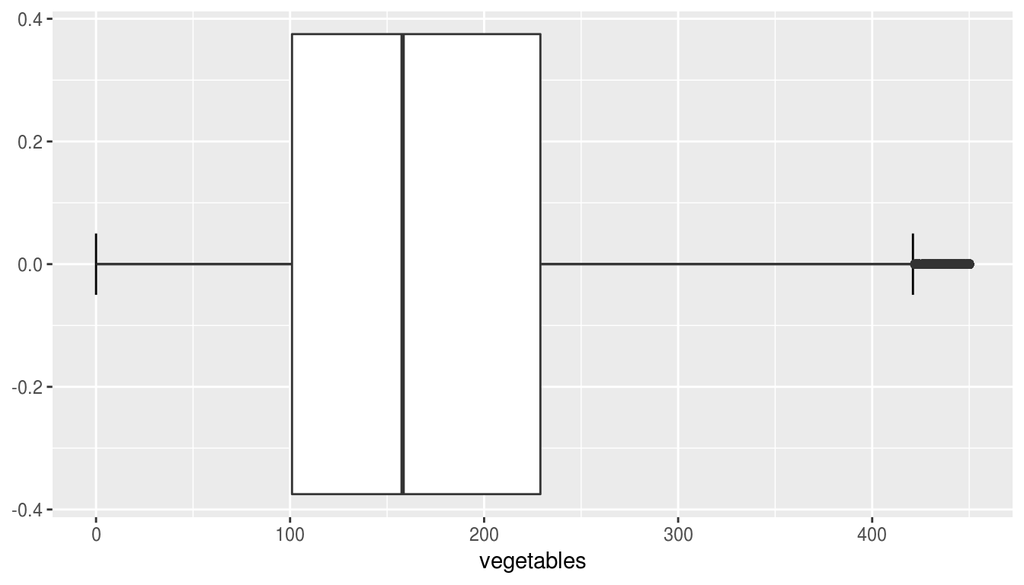

```r
ggplot(data.frame(vegetables), aes(y=vegetables)) + stat_boxplot(geom = 'errorbar', width = 0.1) + geom_boxplot() + coord_flip()
```

Now, let’s try to answer to the research question, is there any relation between weight and vegetables consumption?

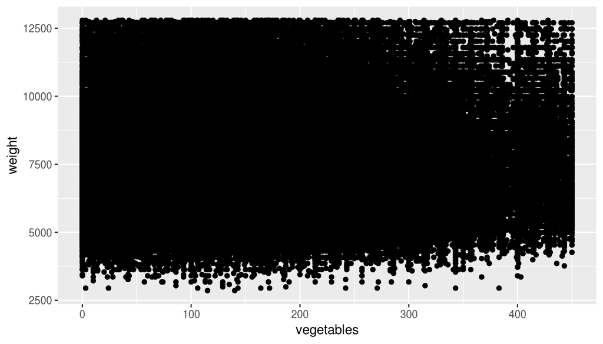

```r
ggplot(weight.vegetables, aes(x=vegetables, y=weight)) + geom_point()
```

Wow. The scatterplot is so dense, so it’s absolutely impossible to find any kind of relation here. We can make things a bit clearer by reducing sample size and make point more transparent to reflect the density.

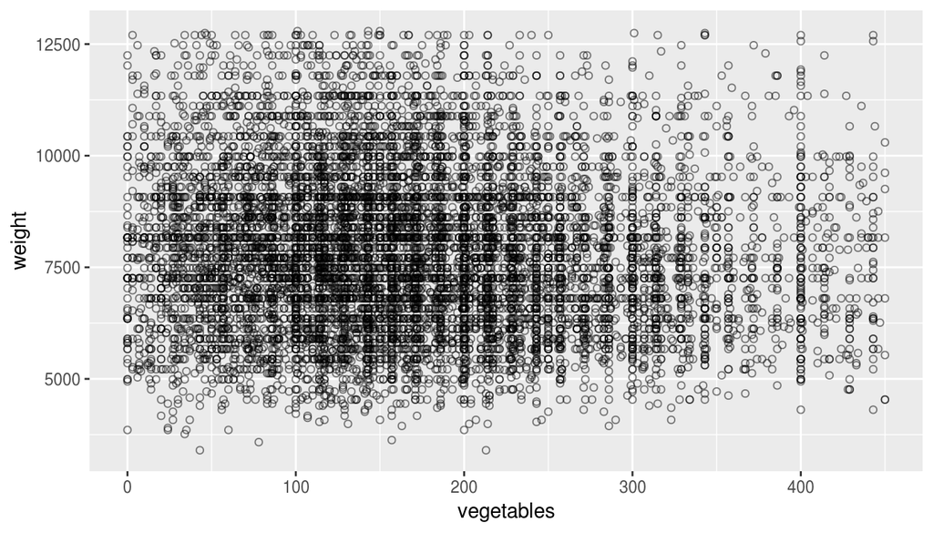

```r
ggplot(sample_n(weight.vegetables, 10000), aes(x=vegetables, y=weight)) + geom_point(shape=1, alpha = 0.5)
```

While there is recognized some ‘cloud’ with high density, still nothing. Let’s add regression line to the plot.

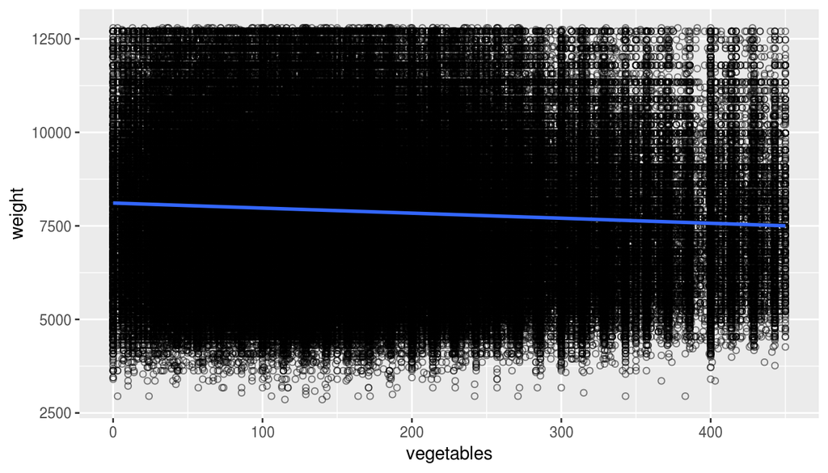

```r
ggplot(weight.vegetables, aes(x=vegetables, y=weight)) + geom_point(shape=1, alpha = 0.5) + geom_smooth(method='lm', se = FALSE)
```

Now we can see that there is small negative relation between weight and vegetables consumption. So there is a small chance the lighter people are, the more they eat vegetables. But for confidence, let’s check the correlation coefficient between weight and vegetables.

```r
cor(weight.vegetables)
```

```
##                 weight  vegetables
## weight      1.00000000 -0.07350818
## vegetables -0.07350818  1.00000000
```

This table confirms the suggestion about small negative relation.

**Research quesion 3: Is self employed mans who sleeps less than it is necessary, drink more alcohol than employed mans with normal sleep?**

The main idea behind this investigation is the next: self employed who sleeps less are working hard and so under pressure and they need to releive stress, while employed with normal sleep don’t.

Let’s find in codebook variables we can use to make this research. We will look for something about sex, employment status, sleep hours and alcohol consumption.

With the sex all is simple, it’s ‘sex’ variable.

```r
str(brfss2013$sex)
```

```
##  Factor w/ 2 levels "Male","Female": 2 2 2 2 1 2 2 2 1 2 ...
```

```r
brfss2013 %>%
  group_by(sex) %>%
  summarize(count=n())
```

```
## # A tibble: 3 x 2
##   sex     count
##   <fct>   <int>
## 1 Male   201313
## 2 Female 290455
## 3 <NA>        7
```

As for employment status, it’s ‘employ1’ variable. Take a look at it quickly.

```r
str(brfss2013$employ1)
```

```
##  Factor w/ 8 levels "Employed for wages",..: 7 1 1 7 7 1 1 7 7 5 ...
```

```r
levels(brfss2013$employ1)
```

```
## [1] "Employed for wages"               "Self-employed"
## [3] "Out of work for 1 year or more"   "Out of work for less than 1 year"
## [5] "A homemaker"                      "A student"
## [7] "Retired"                          "Unable to work"
```

```r
brfss2013 %>%
  group_by(employ1) %>%
  summarize(count=n())
```

```
## # A tibble: 9 x 2
##   employ1                           count
##   <fct>                             <int>
## 1 Employed for wages               202200
## 2 Self-employed                     39832
## 3 Out of work for 1 year or more    14074
## 4 Out of work for less than 1 year  12242
## 5 A homemaker                       31647
## 6 A student                         12682
## 7 Retired                          138259
## 8 Unable to work                    37453
## 9 <NA>                               3386
```

It’s have enough data to split employed for wages and self employed people, so we can use it in research.

For filtering peoples by sleep adequacy, we should use ‘sleptim1’ variable, because it’s the only one about sleep hours. In questionary, the question about sleep is looks the next: ‘On average, how many hours of sleep do you get in a 24-hour period?’, so we should decide ourselves how to split adequate/inadequate hours, but now let’s just take a look at what the variable is.

```r
str(brfss2013$sleptim1)
```

```
##  int [1:491775] NA 6 9 8 6 8 7 6 8 8 ...
```

```r
brfss2013 %>%
  group_by(sleptim1) %>%
  summarize(count=n())
```

```
## # A tibble: 28 x 2
##    sleptim1  count
##       <int>  <int>
##  1        0      1
##  2        1    228
##  3        2   1076
##  4        3   3496
##  5        4  14261
##  6        5  33436
##  7        6 106197
##  8        7 142469
##  9        8 141102
## 10        9  23800
## # … with 18 more rows
```

Seems good enough to use in research. Go further.

As for alcohol consumption, the variable ‘alcday5’, Days In Past 30 Had Alcoholic Beverage, looks the most reasonable one, because other alcohol related variables have too much missing values.

```r
str(brfss2013$alcday5)
```

```
##  int [1:491775] 201 0 220 208 210 0 201 202 101 0 ...
```

```r
brfss2013 %>%
  group_by(alcday5) %>%
  summarize(count=n())
```

```
## # A tibble: 41 x 2
##    alcday5  count
##      <int>  <int>
##  1       0 236715
##  2       1      1
##  3       2      3
##  4     101  18241
##  5     102  14234
##  6     103   9684
##  7     104   4528
##  8     105   4625
##  9     106   1600
## 10     107  10153
## # … with 31 more rows
```

[101 - 199] Days per week, [201 - 299] Days in the past 30 days - so we will need to transform them to one view.

Now, when all variables has been chosen, we will extract them into new data frame and will get rid of rows with any NA at the same time.

```r
employment.sleep.alcohol <- data.frame(
  sex=brfss2013$sex,
  employment=brfss2013$employ1,
  sleep=brfss2013$sleptim1,
  alcohol=brfss2013$alcday5
) %>% na.omit()

head(employment.sleep.alcohol)
```

```
##      sex         employment sleep alcohol
## 2 Female Employed for wages     6       0
## 3 Female Employed for wages     9     220
## 4 Female            Retired     8     208
## 5   Male            Retired     6     210
## 6 Female Employed for wages     8       0
## 7 Female Employed for wages     7     201
```

```r
anyNA(employment.sleep.alcohol)
```

```
## [1] FALSE
```

Filter new dataset and drop sex column.

```r
employment.sleep.alcohol <- employment.sleep.alcohol %>% filter(sex == 'Male' & employment %in% c('Self-employed', 'Employed for wages')) %>% select(-c(sex))
head(employment.sleep.alcohol)
```

```
##           employment sleep alcohol
## 1 Employed for wages     6     205
## 2 Employed for wages     8     204
## 3 Employed for wages     8     105
## 4 Employed for wages     7     203
## 5 Employed for wages     8       0
## 6 Employed for wages     6     202
```

That’s a moot point, what sleep we can consider as inadequate, so, based on the opionin the adult person should sleeps 7-9 hours per day, let’s take 6 hours as an upper bound of the inadequate sleep.

```r
employment.sleep.alcohol <- employment.sleep.alcohol %>% mutate(sleep = if_else(sleep > 6, 'Adequate', 'Inadequate'))
head(employment.sleep.alcohol)
```

```
##           employment      sleep alcohol
## 1 Employed for wages Inadequate     205
## 2 Employed for wages   Adequate     204
## 3 Employed for wages   Adequate     105
## 4 Employed for wages   Adequate     203
## 5 Employed for wages   Adequate       0
## 6 Employed for wages Inadequate     202
```

Calculate variable we are interested in and drop not needed.

```r
employment.sleep.alcohol <- employment.sleep.alcohol %>%
  filter((employment == 'Employed for wages' & sleep == 'Adequate') | (employment == 'Self-employed' & sleep == 'Inadequate'))
head(employment.sleep.alcohol)
```

```
##           employment    sleep alcohol
## 1 Employed for wages Adequate     204
## 2 Employed for wages Adequate     105
## 3 Employed for wages Adequate     203
## 4 Employed for wages Adequate       0
## 5 Employed for wages Adequate       0
## 6 Employed for wages Adequate     103
```

Make ‘alcohol’ variable monotonous, transform it to drinking days per month, i.e, if value is 0, return it, if value is greater than or equal to 200, substract 200, if less than or equal to 107, subsctract 100, divide by 7 and multiply to 30.

```r
employment.sleep.alcohol <- employment.sleep.alcohol %>%
  mutate(alcohol = case_when(
    alcohol == 0 ~ 0,
    (alcohol >= 100 & alcohol <= 107) ~ round((alcohol - 100)/7 * 30),
    alcohol >= 200 ~ alcohol - 200
  )
)
head(employment.sleep.alcohol)
```

```
##           employment    sleep alcohol
## 1 Employed for wages Adequate       4
## 2 Employed for wages Adequate      21
## 3 Employed for wages Adequate       3
## 4 Employed for wages Adequate       0
## 5 Employed for wages Adequate       0
## 6 Employed for wages Adequate      13
```

And now it’s time to give an answer to the main question.

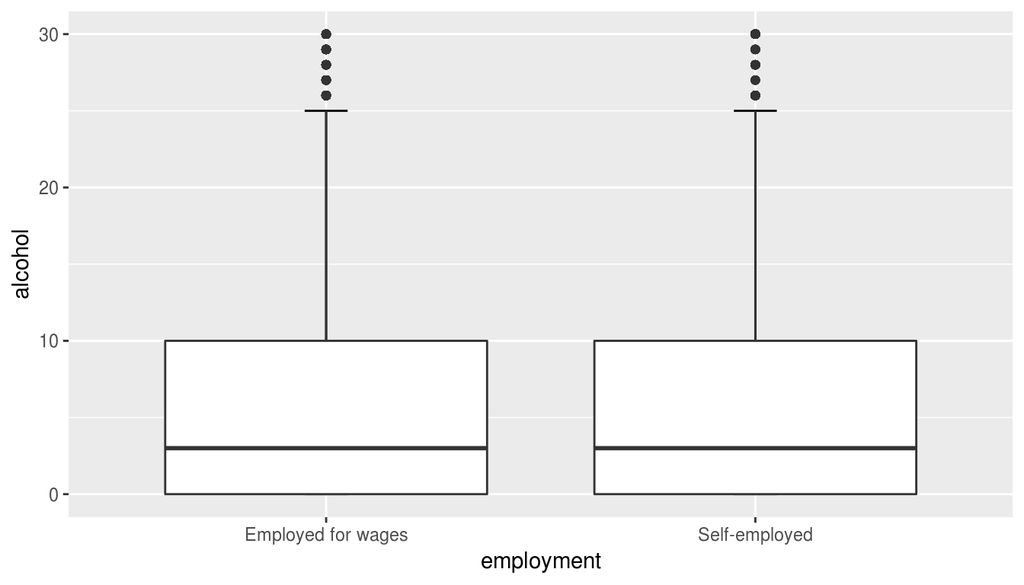

```r
ggplot(data.frame(employment.sleep.alcohol), aes(x=employment, y=alcohol)) + stat_boxplot(geom = 'errorbar', width = 0.1) + geom_boxplot()
```

Wow, not the expected result. It seems there is no defference in alcohol consumption between self employed who sleeps little, and employed for wages who sleeps enough.